# Optimal Treatment Analysis

## Outcome Variable

**Outcome Variable:** ever_stunted

## Predictor Variables

**Intervention Variable:** single

**Adjustment Set:**

- arm
- W_mage
- meducyrs
- feducyrs
- W_mhtcm
- W_mwtkg
- W_mbmi
- delta_W_mage
- delta_meducyrs
- delta_feducyrs
- delta_W_mhtcm
- delta_W_mwtkg
- delta_W_mbmi

## Stratifying Variables

The analysis was stratified on these variable(s):

- agecat
- studyid
- country

## Data Summary

| agecat | studyid | country | single | ever_stunted | n_cell | n |
| --- | --- | --- | --- | --- | --- | --- |
| 0-24 months | ki0047075b-MAL-ED | BANGLADESH | 0 | 0 | 104 | 265 |
| 0-24 months | ki0047075b-MAL-ED | BANGLADESH | 0 | 1 | 161 | 265 |
| 0-24 months | ki0047075b-MAL-ED | BANGLADESH | 1 | 0 | 0 | 265 |
| 0-24 months | ki0047075b-MAL-ED | BANGLADESH | 1 | 1 | 0 | 265 |
| 0-24 months | ki0047075b-MAL-ED | BRAZIL | 0 | 0 | 154 | 233 |
| 0-24 months | ki0047075b-MAL-ED | BRAZIL | 0 | 1 | 43 | 233 |
| 0-24 months | ki0047075b-MAL-ED | BRAZIL | 1 | 0 | 25 | 233 |
| 0-24 months | ki0047075b-MAL-ED | BRAZIL | 1 | 1 | 11 | 233 |
| 0-24 months | ki0047075b-MAL-ED | INDIA | 0 | 0 | 101 | 249 |
| 0-24 months | ki0047075b-MAL-ED | INDIA | 0 | 1 | 148 | 249 |
| 0-24 months | ki0047075b-MAL-ED | INDIA | 1 | 0 | 0 | 249 |
| 0-24 months | ki0047075b-MAL-ED | INDIA | 1 | 1 | 0 | 249 |
| 0-24 months | ki0047075b-MAL-ED | NEPAL | 0 | 0 | 157 | 240 |
| 0-24 months | ki0047075b-MAL-ED | NEPAL | 0 | 1 | 83 | 240 |
| 0-24 months | ki0047075b-MAL-ED | NEPAL | 1 | 0 | 0 | 240 |
| 0-24 months | ki0047075b-MAL-ED | NEPAL | 1 | 1 | 0 | 240 |
| 0-24 months | ki0047075b-MAL-ED | PERU | 0 | 0 | 101 | 303 |
| 0-24 months | ki0047075b-MAL-ED | PERU | 0 | 1 | 167 | 303 |
| 0-24 months | ki0047075b-MAL-ED | PERU | 1 | 0 | 14 | 303 |
| 0-24 months | ki0047075b-MAL-ED | PERU | 1 | 1 | 21 | 303 |
| 0-24 months | ki0047075b-MAL-ED | SOUTH AFRICA | 0 | 0 | 82 | 314 |
| 0-24 months | ki0047075b-MAL-ED | SOUTH AFRICA | 0 | 1 | 94 | 314 |
| 0-24 months | ki0047075b-MAL-ED | SOUTH AFRICA | 1 | 0 | 61 | 314 |
| 0-24 months | ki0047075b-MAL-ED | SOUTH AFRICA | 1 | 1 | 77 | 314 |
| 0-24 months | ki0047075b-MAL-ED | TANZANIA, UNITED REPUBLIC OF | 0 | 0 | 38 | 262 |
| 0-24 months | ki0047075b-MAL-ED | TANZANIA, UNITED REPUBLIC OF | 0 | 1 | 214 | 262 |
| 0-24 months | ki0047075b-MAL-ED | TANZANIA, UNITED REPUBLIC OF | 1 | 0 | 3 | 262 |
| 0-24 months | ki0047075b-MAL-ED | TANZANIA, UNITED REPUBLIC OF | 1 | 1 | 7 | 262 |
| 0-24 months | ki1066203-TanzaniaChild2 | TANZANIA, UNITED REPUBLIC OF | 0 | 0 | 1400 | 2375 |
| 0-24 months | ki1066203-TanzaniaChild2 | TANZANIA, UNITED REPUBLIC OF | 0 | 1 | 751 | 2375 |

[output cut: 138 more lines]

The following strata were considered:

- agecat: 0-24 months, studyid: ki0047075b-MAL-ED, country: BANGLADESH
- agecat: 0-24 months, studyid: ki0047075b-MAL-ED, country: BRAZIL
- agecat: 0-24 months, studyid: ki0047075b-MAL-ED, country: INDIA
- agecat: 0-24 months, studyid: ki0047075b-MAL-ED, country: NEPAL
- agecat: 0-24 months, studyid: ki0047075b-MAL-ED, country: PERU
- agecat: 0-24 months, studyid: ki0047075b-MAL-ED, country: SOUTH AFRICA
- agecat: 0-24 months, studyid: ki0047075b-MAL-ED, country: TANZANIA, UNITED REPUBLIC OF
- agecat: 0-24 months, studyid: ki1066203-TanzaniaChild2, country: TANZANIA, UNITED REPUBLIC OF
- agecat: 0-24 months, studyid: ki1112895-Guatemala BSC, country: GUATEMALA
- agecat: 0-24 months, studyid: ki1119695-PROBIT, country: BELARUS
- agecat: 0-24 months, studyid: ki1126311-ZVITAMBO, country: ZIMBABWE
- agecat: 0-24 months, studyid: ki1135781-COHORTS, country: GUATEMALA
- agecat: 0-24 months, studyid: ki1135781-COHORTS, country: INDIA
- agecat: 0-24 months, studyid: ki1135781-COHORTS, country: PHILIPPINES
- agecat: 0-6 months, studyid: ki0047075b-MAL-ED, country: BANGLADESH
- agecat: 0-6 months, studyid: ki0047075b-MAL-ED, country: BRAZIL
- agecat: 0-6 months, studyid: ki0047075b-MAL-ED, country: INDIA
- agecat: 0-6 months, studyid: ki0047075b-MAL-ED, country: NEPAL
- agecat: 0-6 months, studyid: ki0047075b-MAL-ED, country: PERU
- agecat: 0-6 months, studyid: ki0047075b-MAL-ED, country: SOUTH AFRICA
- agecat: 0-6 months, studyid: ki0047075b-MAL-ED, country: TANZANIA, UNITED REPUBLIC OF
- agecat: 0-6 months, studyid: ki1066203-TanzaniaChild2, country: TANZANIA, UNITED REPUBLIC OF
- agecat: 0-6 months, studyid: ki1112895-Guatemala BSC, country: GUATEMALA
- agecat: 0-6 months, studyid: ki1119695-PROBIT, country: BELARUS
- agecat: 0-6 months, studyid: ki1126311-ZVITAMBO, country: ZIMBABWE
- agecat: 0-6 months, studyid: ki1135781-COHORTS, country: GUATEMALA
- agecat: 0-6 months, studyid: ki1135781-COHORTS, country: INDIA
- agecat: 0-6 months, studyid: ki1135781-COHORTS, country: PHILIPPINES
- agecat: 6-24 months, studyid: ki0047075b-MAL-ED, country: BANGLADESH
- agecat: 6-24 months, studyid: ki0047075b-MAL-ED, country: BRAZIL
- agecat: 6-24 months, studyid: ki0047075b-MAL-ED, country: INDIA
- agecat: 6-24 months, studyid: ki0047075b-MAL-ED, country: NEPAL
- agecat: 6-24 months, studyid: ki0047075b-MAL-ED, country: PERU
- agecat: 6-24 months, studyid: ki0047075b-MAL-ED, country: SOUTH AFRICA
- agecat: 6-24 months, studyid: ki0047075b-MAL-ED, country: TANZANIA, UNITED REPUBLIC OF
- agecat: 6-24 months, studyid: ki1066203-TanzaniaChild2, country: TANZANIA, UNITED REPUBLIC OF
- agecat: 6-24 months, studyid: ki1112895-Guatemala BSC, country: GUATEMALA
- agecat: 6-24 months, studyid: ki1119695-PROBIT, country: BELARUS
- agecat: 6-24 months, studyid: ki1126311-ZVITAMBO, country: ZIMBABWE
- agecat: 6-24 months, studyid: ki1135781-COHORTS, country: GUATEMALA
- agecat: 6-24 months, studyid: ki1135781-COHORTS, country: INDIA
- agecat: 6-24 months, studyid: ki1135781-COHORTS, country: PHILIPPINES

### Dropped Strata

Some strata were dropped due to rare outcomes:

- agecat: 0-24 months, studyid: ki0047075b-MAL-ED, country: BANGLADESH
- agecat: 0-24 months, studyid: ki0047075b-MAL-ED, country: INDIA
- agecat: 0-24 months, studyid: ki0047075b-MAL-ED, country: NEPAL
- agecat: 0-24 months, studyid: ki0047075b-MAL-ED, country: TANZANIA, UNITED REPUBLIC OF
- agecat: 0-24 months, studyid: ki1135781-COHORTS, country: INDIA
- agecat: 0-6 months, studyid: ki0047075b-MAL-ED, country: BANGLADESH
- agecat: 0-6 months, studyid: ki0047075b-MAL-ED, country: INDIA
- agecat: 0-6 months, studyid: ki0047075b-MAL-ED, country: NEPAL
- agecat: 0-6 months, studyid: ki0047075b-MAL-ED, country: TANZANIA, UNITED REPUBLIC OF
- agecat: 0-6 months, studyid: ki1135781-COHORTS, country: INDIA
- agecat: 6-24 months, studyid: ki0047075b-MAL-ED, country: BANGLADESH
- agecat: 6-24 months, studyid: ki0047075b-MAL-ED, country: BRAZIL
- agecat: 6-24 months, studyid: ki0047075b-MAL-ED, country: INDIA
- agecat: 6-24 months, studyid: ki0047075b-MAL-ED, country: NEPAL
- agecat: 6-24 months, studyid: ki0047075b-MAL-ED, country: TANZANIA, UNITED REPUBLIC OF
- agecat: 6-24 months, studyid: ki1135781-COHORTS, country: INDIA

## Methods Detail

We’re interested in the causal parameters $E[Y_a]$ for all values of $a \in \mathcal{A}$. These parameters represent the mean outcome if, possibly contrary to fact, we intervened to set all units to have $A=a$. Under the randomization and positivity assumptions, these are identified by the statistical parameters $\psi_a=E_W[E_{Y|A,W}(Y|A=a,W)]$. In addition, we’re interested in the mean of $Y$, $E[Y]$ under no intervention (the observed mean). We will estimate these parameters by using SuperLearner to fit the relevant likelihood factors – $E_{Y|A,W}(Y|A=a,W)$ and $p(A=a|W)$, and then updating our likelihood fit using a joint TMLE.

For unadjusted analyses ($W=\{\}$), initial likelihoods were estimated using Lrnr_glm to estimate the simple $E(Y|A)$ and Lrnr_mean to estimate $p(A)$. For adjusted analyses, a small library containing Lrnr_glmnet, Lrnr_xgboost, and Lrnr_mean was used.

Having estimated these parameters, we will then use the delta method to estimate relative risks and attributable risks relative to a prespecified baseline level of $A$.

# Results Detail

## Results Plots

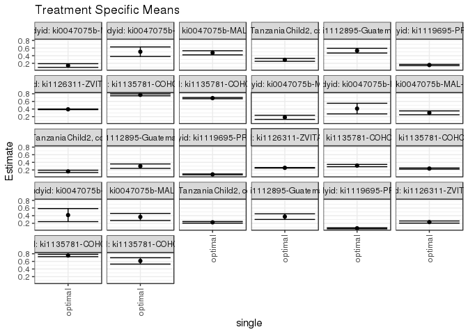

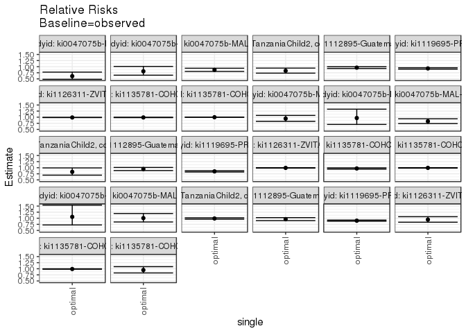

## Results Table

### Parameter: TSM

| agecat | studyid | country | intervention_level | baseline_level | estimate | ci_lower | ci_upper |
| --- | --- | --- | --- | --- | --- | --- | --- |
| 0-24 months | ki0047075b-MAL-ED | BRAZIL | optimal | NA | 0.1423862 | 0.0939415 | 0.1908309 |
| 0-24 months | ki0047075b-MAL-ED | PERU | optimal | NA | 0.5046118 | 0.3796673 | 0.6295563 |
| 0-24 months | ki0047075b-MAL-ED | SOUTH AFRICA | optimal | NA | 0.4760484 | 0.4215024 | 0.5305944 |
| 0-24 months | ki1066203-TanzaniaChild2 | TANZANIA, UNITED REPUBLIC OF | optimal | NA | 0.2911140 | 0.2531732 | 0.3290548 |
| 0-24 months | ki1112895-Guatemala BSC | GUATEMALA | optimal | NA | 0.5320243 | 0.4703063 | 0.5937424 |
| 0-24 months | ki1119695-PROBIT | BELARUS | optimal | NA | 0.1554890 | 0.1386518 | 0.1723262 |
| 0-24 months | ki1126311-ZVITAMBO | ZIMBABWE | optimal | NA | 0.3923763 | 0.3840512 | 0.4007014 |
| 0-24 months | ki1135781-COHORTS | GUATEMALA | optimal | NA | 0.7717367 | 0.7470577 | 0.7964158 |
| 0-24 months | ki1135781-COHORTS | PHILIPPINES | optimal | NA | 0.6862518 | 0.6694921 | 0.7030115 |
| 0-6 months | ki0047075b-MAL-ED | BRAZIL | optimal | NA | 0.1823204 | 0.1282391 | 0.2364017 |
| 0-6 months | ki0047075b-MAL-ED | PERU | optimal | NA | 0.4113326 | 0.2721567 | 0.5505084 |
| 0-6 months | ki0047075b-MAL-ED | SOUTH AFRICA | optimal | NA | 0.2998623 | 0.2494945 | 0.3502301 |
| 0-6 months | ki1066203-TanzaniaChild2 | TANZANIA, UNITED REPUBLIC OF | optimal | NA | 0.1636980 | 0.1334811 | 0.1939149 |
| 0-6 months | ki1112895-Guatemala BSC | GUATEMALA | optimal | NA | 0.2998548 | 0.2420867 | 0.3576229 |
| 0-6 months | ki1119695-PROBIT | BELARUS | optimal | NA | 0.0844622 | 0.0732014 | 0.0957231 |
| 0-6 months | ki1126311-ZVITAMBO | ZIMBABWE | optimal | NA | 0.2564188 | 0.2489844 | 0.2638531 |
| 0-6 months | ki1135781-COHORTS | GUATEMALA | optimal | NA | 0.3150799 | 0.2850682 | 0.3450916 |
| 0-6 months | ki1135781-COHORTS | PHILIPPINES | optimal | NA | 0.2367915 | 0.2214411 | 0.2521420 |
| 6-24 months | ki0047075b-MAL-ED | PERU | optimal | NA | 0.4150933 | 0.2437888 | 0.5863978 |
| 6-24 months | ki0047075b-MAL-ED | SOUTH AFRICA | optimal | NA | 0.3661029 | 0.2732345 | 0.4589713 |
| 6-24 months | ki1066203-TanzaniaChild2 | TANZANIA, UNITED REPUBLIC OF | optimal | NA | 0.2254611 | 0.2040265 | 0.2468956 |
| 6-24 months | ki1112895-Guatemala BSC | GUATEMALA | optimal | NA | 0.3746194 | 0.3012144 | 0.4480245 |
| 6-24 months | ki1119695-PROBIT | BELARUS | optimal | NA | 0.0689451 | 0.0556469 | 0.0822432 |
| 6-24 months | ki1126311-ZVITAMBO | ZIMBABWE | optimal | NA | 0.2325458 | 0.2040101 | 0.2610816 |
| 6-24 months | ki1135781-COHORTS | GUATEMALA | optimal | NA | 0.7545573 | 0.7239049 | 0.7852096 |
| 6-24 months | ki1135781-COHORTS | PHILIPPINES | optimal | NA | 0.6118617 | 0.5284242 | 0.6952992 |

### Parameter: E(Y)

| agecat | studyid | country | intervention_level | baseline_level | estimate | ci_lower | ci_upper |
| --- | --- | --- | --- | --- | --- | --- | --- |
| 0-24 months | ki0047075b-MAL-ED | BRAZIL | observed | NA | 0.2329077 | 0.1786112 | 0.2872042 |
| 0-24 months | ki0047075b-MAL-ED | PERU | observed | NA | 0.6228135 | 0.5680830 | 0.6775441 |
| 0-24 months | ki0047075b-MAL-ED | SOUTH AFRICA | observed | NA | 0.5489821 | 0.4938109 | 0.6041533 |
| 0-24 months | ki1066203-TanzaniaChild2 | TANZANIA, UNITED REPUBLIC OF | observed | NA | 0.3500968 | 0.3309330 | 0.3692606 |
| 0-24 months | ki1112895-Guatemala BSC | GUATEMALA | observed | NA | 0.5536757 | 0.4955467 | 0.6118048 |
| 0-24 months | ki1119695-PROBIT | BELARUS | observed | NA | 0.1677770 | 0.1490964 | 0.1864576 |
| 0-24 months | ki1126311-ZVITAMBO | ZIMBABWE | observed | NA | 0.3967930 | 0.3886933 | 0.4048927 |
| 0-24 months | ki1135781-COHORTS | GUATEMALA | observed | NA | 0.7795447 | 0.7561508 | 0.8029386 |
| 0-24 months | ki1135781-COHORTS | PHILIPPINES | observed | NA | 0.6867801 | 0.6702317 | 0.7033286 |
| 0-6 months | ki0047075b-MAL-ED | BRAZIL | observed | NA | 0.1933530 | 0.1425566 | 0.2441495 |
| 0-6 months | ki0047075b-MAL-ED | PERU | observed | NA | 0.4257253 | 0.3699591 | 0.4814916 |
| 0-6 months | ki0047075b-MAL-ED | SOUTH AFRICA | observed | NA | 0.3608881 | 0.3077161 | 0.4140602 |
| 0-6 months | ki1066203-TanzaniaChild2 | TANZANIA, UNITED REPUBLIC OF | observed | NA | 0.1971626 | 0.1812006 | 0.2131246 |
| 0-6 months | ki1112895-Guatemala BSC | GUATEMALA | observed | NA | 0.3172227 | 0.2610948 | 0.3733507 |
| 0-6 months | ki1119695-PROBIT | BELARUS | observed | NA | 0.0993193 | 0.0862747 | 0.1123639 |
| 0-6 months | ki1126311-ZVITAMBO | ZIMBABWE | observed | NA | 0.2582441 | 0.2509932 | 0.2654949 |
| 0-6 months | ki1135781-COHORTS | GUATEMALA | observed | NA | 0.3251995 | 0.2957832 | 0.3546159 |
| 0-6 months | ki1135781-COHORTS | PHILIPPINES | observed | NA | 0.2384014 | 0.2231930 | 0.2536097 |
| 6-24 months | ki0047075b-MAL-ED | PERU | observed | NA | 0.3928010 | 0.3140097 | 0.4715923 |
| 6-24 months | ki0047075b-MAL-ED | SOUTH AFRICA | observed | NA | 0.3640452 | 0.2889872 | 0.4391032 |
| 6-24 months | ki1066203-TanzaniaChild2 | TANZANIA, UNITED REPUBLIC OF | observed | NA | 0.2277185 | 0.2070896 | 0.2483474 |
| 6-24 months | ki1112895-Guatemala BSC | GUATEMALA | observed | NA | 0.3892521 | 0.3188034 | 0.4597008 |
| 6-24 months | ki1119695-PROBIT | BELARUS | observed | NA | 0.0766238 | 0.0626584 | 0.0905891 |
| 6-24 months | ki1126311-ZVITAMBO | ZIMBABWE | observed | NA | 0.2465840 | 0.2371009 | 0.2560671 |
| 6-24 months | ki1135781-COHORTS | GUATEMALA | observed | NA | 0.7622081 | 0.7330506 | 0.7913656 |
| 6-24 months | ki1135781-COHORTS | PHILIPPINES | observed | NA | 0.6452463 | 0.6247635 | 0.6657291 |

### Parameter: RR

| agecat | studyid | country | intervention_level | baseline_level | estimate | ci_lower | ci_upper |
| --- | --- | --- | --- | --- | --- | --- | --- |
| 0-24 months | ki0047075b-MAL-ED | BRAZIL | optimal | observed | 0.6113418 | 0.4820130 | 0.7753708 |
| 0-24 months | ki0047075b-MAL-ED | PERU | optimal | observed | 0.8102133 | 0.6505353 | 1.0090851 |
| 0-24 months | ki0047075b-MAL-ED | SOUTH AFRICA | optimal | observed | 0.8671474 | 0.8043764 | 0.9348169 |
| 0-24 months | ki1066203-TanzaniaChild2 | TANZANIA, UNITED REPUBLIC OF | optimal | observed | 0.8315244 | 0.7345401 | 0.9413140 |
| 0-24 months | ki1112895-Guatemala BSC | GUATEMALA | optimal | observed | 0.9608952 | 0.9260012 | 0.9971040 |
| 0-24 months | ki1119695-PROBIT | BELARUS | optimal | observed | 0.9267598 | 0.8989399 | 0.9554405 |
| 0-24 months | ki1126311-ZVITAMBO | ZIMBABWE | optimal | observed | 0.9888692 | 0.9832156 | 0.9945553 |
| 0-24 months | ki1135781-COHORTS | GUATEMALA | optimal | observed | 0.9899839 | 0.9824946 | 0.9975303 |
| 0-24 months | ki1135781-COHORTS | PHILIPPINES | optimal | observed | 0.9992307 | 0.9955679 | 1.0029071 |
| 0-6 months | ki0047075b-MAL-ED | BRAZIL | optimal | observed | 0.9429403 | 0.8285869 | 1.0730756 |
| 0-6 months | ki0047075b-MAL-ED | PERU | optimal | observed | 0.9661924 | 0.7026328 | 1.3286138 |
| 0-6 months | ki0047075b-MAL-ED | SOUTH AFRICA | optimal | observed | 0.8309010 | 0.7386806 | 0.9346348 |
| 0-6 months | ki1066203-TanzaniaChild2 | TANZANIA, UNITED REPUBLIC OF | optimal | observed | 0.8302691 | 0.6947972 | 0.9921554 |
| 0-6 months | ki1112895-Guatemala BSC | GUATEMALA | optimal | observed | 0.9452502 | 0.8837098 | 1.0110761 |
| 0-6 months | ki1119695-PROBIT | BELARUS | optimal | observed | 0.8504111 | 0.8238397 | 0.8778395 |
| 0-6 months | ki1126311-ZVITAMBO | ZIMBABWE | optimal | observed | 0.9929319 | 0.9855106 | 1.0004092 |
| 0-6 months | ki1135781-COHORTS | GUATEMALA | optimal | observed | 0.9688817 | 0.9436398 | 0.9947988 |
| 0-6 months | ki1135781-COHORTS | PHILIPPINES | optimal | observed | 0.9932473 | 0.9830294 | 1.0035715 |
| 6-24 months | ki0047075b-MAL-ED | PERU | optimal | observed | 1.0567520 | 0.7257896 | 1.5386343 |
| 6-24 months | ki0047075b-MAL-ED | SOUTH AFRICA | optimal | observed | 1.0056522 | 0.8469203 | 1.1941341 |
| 6-24 months | ki1066203-TanzaniaChild2 | TANZANIA, UNITED REPUBLIC OF | optimal | observed | 0.9900866 | 0.9613656 | 1.0196657 |
| 6-24 months | ki1112895-Guatemala BSC | GUATEMALA | optimal | observed | 0.9624084 | 0.9031401 | 1.0255661 |
| 6-24 months | ki1119695-PROBIT | BELARUS | optimal | observed | 0.8997870 | 0.8764492 | 0.9237463 |
| 6-24 months | ki1126311-ZVITAMBO | ZIMBABWE | optimal | observed | 0.9430695 | 0.8365770 | 1.0631180 |
| 6-24 months | ki1135781-COHORTS | GUATEMALA | optimal | observed | 0.9899623 | 0.9804452 | 0.9995717 |
| 6-24 months | ki1135781-COHORTS | PHILIPPINES | optimal | observed | 0.9482606 | 0.8283780 | 1.0854926 |